# Power and model building

p-values, power, uncertainty and building models

Dr Massimiliano Canzi

# What p-values are not

`Did you know:` slow lorises are the only known venomous primates. Glands on the inside of their elbows make a secretion that turns venomous when mixed with saliva.

*Source: San Diego Zoo Wildlife Alliance*

## Today

The key points of three chapters of Winter (2019):

| Chapter | Topics |
| --- | --- |
| 10 | what p-values are not; power; Type I, II, M and S errors; multiple testing; stopping rules |
| 11 | confidence intervals, testing predictors with several levels, plotting uncertainty |
| 16 | strategies for model building, reproducible research |

Most of today is simulation: we make up a world where we know the truth, and see how our methods behave in it.

## So far

Lecture 9 introduced p-values, standard errors and confidence intervals, and showed that significance says nothing about size. Lectures 10 to 12 added mixed models with `lmer()` and `glmer()`, tested with likelihood ratio tests.

Today: how p-values can mislead, and how to plan and report models more carefully.

## Common misreadings

A p-value of .03 does **not** mean:

- that there is a 3% chance that the null hypothesis is true
- that there is a 97% chance that the effect is real
- that the effect is large or important

It means: if the null hypothesis were true, data at least this extreme would turn up 3% of the time.

## Absence of evidence

p > .05 does **not** mean that there is no effect.

The data are compatible with no effect, and they may be just as compatible with a large one, so look at the confidence interval. A small study can also miss a real effect; that is a question of power, which comes next.

## Significant vs not significant

Two studies of the same effect (Gelman & Stern, 2006):

|  | Estimate | SE | p |  |
| --- | --- | --- | --- | --- |
| Study A | 25 | 10 | .01 | significant |
| Study B | 10 | 10 | .32 | not significant |

Do the two studies disagree? Test the difference:

```r
diff    <- 25 - 10
se_diff <- sqrt(10^2 + 10^2)
2 * pnorm(-diff / se_diff)
```

```
[1] 0.2888444
```

The difference between them is not significant either. Compare the effects directly, not their p-values.

# Power and errors

`Did you know:` a threatened slow loris clasps its arms over its head. With its face markings, the pose looks like the hood of an angry cobra.

*Source: San Diego Zoo Wildlife Alliance*

## Two ways to be wrong

|  | No effect in reality | Effect in reality |
| --- | --- | --- |
| **Significant** | Type I error (false alarm) | correct |
| **Not significant** | correct | Type II error (miss) |

We choose the Type I error rate, `α`, and usually set it to .05. Power is the probability of finding an effect that is really there, 1 minus the Type II error rate. It grows with the effect size and the sample size, and shrinks as the noise grows.

## Simulating a study

A world we control: group b’s vowels are 10 ms longer than group a’s, SD = 40 ms.

```r
sim_study <- function(n, diff = 10, sd = 40) {
  d <- tibble(group    = rep(c("a", "b"), each = n),
              duration = rnorm(2 * n, mean = 200 + diff * (group == "b"), sd = sd))
  fit <- summary(lm(duration ~ group, data = d))$coefficients
  tibble(estimate = fit[2, 1], p = fit[2, 4])
}

set.seed(42)
one <- sim_study(n = 20)
one
```

```
# A tibble: 1 × 2
  estimate     p
     <dbl> <dbl>
1    -8.52 0.583
```

The true difference is +10 ms. This study, with 20 speakers per group, estimates -8.5 ms (p = 0.58): one study can be far off.

## Run it 1,000 times

```r
set.seed(42)
sims20 <- map(1:1000, \(i) sim_study(n = 20)) |> list_rbind()
mean(sims20$p < .05)
```

```
[1] 0.113
```

The power is about 11%: the effect is real, yet almost 9 studies in 10 miss it. A formula gives the same answer:

```r
power.t.test(n = 20, delta = 10, sd = 40)$power
```

```
[1] 0.1171781
```

## Power and sample size

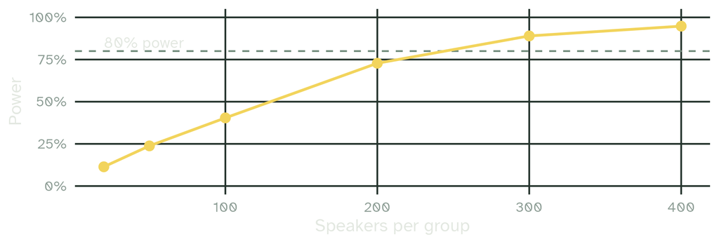

For 80% power, this 10 ms effect needs about 253 speakers per group. Plan the sample size before collecting data.

## Type M and Type S errors

Gelman & Carlin (2014): with low power, the significant results are the misleading ones.

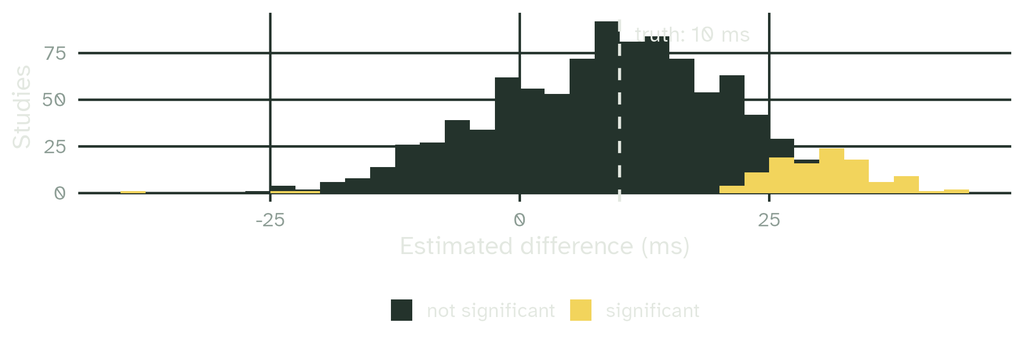

Only the large estimates reach significance.

## Type M and Type S errors

```r
sig <- filter(sims20, p < .05)
mean(abs(sig$estimate))
```

```
[1] 30.47138
```

```r
mean(sig$estimate < 0)
```

```
[1] 0.02654867
```

The true difference is 10 ms. The significant estimates are on average 3 times too large, a Type M (magnitude) error, and 2.7% of them point the wrong way, a Type S (sign) error. So a significant result from a small study probably exaggerates the effect.

## Power for mixed models

For mixed models, there is no simple formula. Do what we just did:

1. Simulate data with your design: participants, items, plausible effect sizes and random effects (lectures 10 to 12)
2. Fit the model to each simulated data set
3. Count how often the effect is significant

The `{simr}` package automates this for `lmer()` and `glmer()` models (Green & MacLeod, 2016).

# Multiple tests and stopping rules

`Did you know:` slow lorises also use their venom on each other: in one study, 57% of males and nearly a third of females showed signs of at least one venomous bite.

*Sources: Nekaris et al. (2020), Current Biology; Mongabay*

## Multiple testing

Each test on a null effect has a 5% chance of a false alarm. With `k` tests:

```r
tibble(k = c(1, 5, 10, 20)) |>
  mutate(at_least_one_false_alarm = 1 - 0.95^k)
```

```
# A tibble: 4 × 2
      k at_least_one_false_alarm
  <dbl>                    <dbl>
1     1                   0.0500
2     5                   0.226
3    10                   0.401
4    20                   0.642
```

If you test 20 effects that do not exist, you will probably find at least one “significant” result.

## A simulation

1,000 studies, each running 10 t-tests on pure noise:

```r
set.seed(3)
any_sig <- map_lgl(1:1000, \(i) {
  p <- map_dbl(1:10, \(j) t.test(rnorm(20), rnorm(20))$p.value)
  any(p < .05)
})
mean(any_sig)
```

```
[1] 0.38
```

About 38% of the studies find “something”.

## Correcting for multiple tests

```r
p <- c(0.003, 0.012, 0.031, 0.048, 0.21)
p.adjust(p, method = "bonferroni")
```

```
[1] 0.015 0.060 0.155 0.240 1.000
```

```r
p.adjust(p, method = "holm")
```

```
[1] 0.015 0.048 0.093 0.096 0.210
```

Bonferroni multiplies each p-value by the number of tests; Holm does something similar, step by step, and loses less power.

Better still: test fewer things. Decide which comparisons answer your question before you look at the data.

## Stopping rules

A tempting plan: test after every 10 participants, and stop as soon as p < .05.

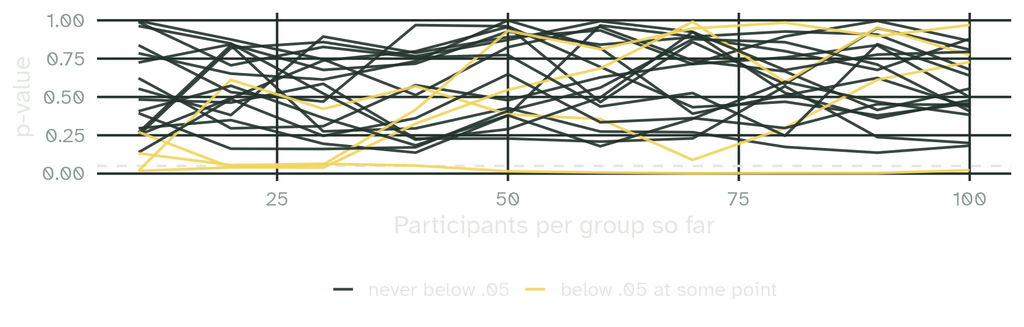

20 studies of no effect: p-values wander, and some dip below .05 by chance.

## Peeking inflates false alarms

```r
peek <- function(max_n = 100, step = 10) {
  a <- rnorm(max_n); b <- rnorm(max_n)
  p <- map_dbl(seq(step, max_n, by = step), \(k) t.test(a[1:k], b[1:k])$p.value)
  any(p < .05)
}
set.seed(5)
false_alarm <- mean(map_lgl(1:1000, \(i) peek()))
false_alarm
```

```
[1] 0.197
```

Both groups come from the same distribution, and `peek()` returns `TRUE` if any of the 10 tests was below .05.

With 10 peeks, the false alarm rate is about 20%, not 5%. Fix the sample size in advance, and report how you chose it.

## Discussion

After 20 participants, your result is p = .07. Your supervisor suggests testing 10 more and checking again.

- What is the problem with this plan?
- What could you do instead, and how would you report what happened honestly?

# Uncertainty in regression

`Did you know:` in cool months, pygmy slow lorises can go into torpor, a short form of hibernation. One study recorded inactivity lasting up to 63 hours.

*Source: San Diego Zoo Wildlife Alliance*

## Confidence intervals for coefficients

```r
pengs <- penguins |> drop_na(body_mass_g, flipper_length_mm, species)
m <- lm(body_mass_g ~ flipper_length_mm, data = pengs)
coef(summary(m))
```

```
                     Estimate Std. Error   t value      Pr(>|t|)
(Intercept)       -5780.83136 305.814504 -18.90306  5.587301e-55
flipper_length_mm    49.68557   1.518404  32.72223 4.370681e-107
```

```r
confint(m)
```

```
                        2.5 %      97.5 %
(Intercept)       -6382.35801 -5179.30471
flipper_length_mm    46.69892    52.67221
```

Each mm of flipper goes with about 50 g of body mass, and the 95% CI runs from 46.7 to 52.7 g: roughly the estimate ± 2 SE.

## Predictors with several levels

```r
m_sp <- lm(body_mass_g ~ species, data = pengs)
coef(summary(m_sp))
```

```
                   Estimate Std. Error    t value      Pr(>|t|)
(Intercept)      3700.66225   37.61935 98.3712321 2.488024e-251
speciesChinstrap   32.42598   67.51168  0.4803018  6.313226e-01
speciesGentoo    1375.35401   56.14797 24.4951686  5.420612e-77
```

Two coefficients, two treatment contrasts against Adelie (lecture 7). But is `species` as a whole a useful predictor?

## Testing the whole predictor

Compare models with and without it, as in lectures 11 and 12:

```r
m_0 <- lm(body_mass_g ~ 1, data = pengs)
anova(m_0, m_sp)
```

```
Analysis of Variance Table

Model 1: body_mass_g ~ 1
Model 2: body_mass_g ~ species
  Res.Df       RSS Df Sum of Sq      F    Pr(>F)
1    341 219307697
2    339  72443483  2 146864214 343.63 < 2.2e-16 ***
---
Signif. codes:  0 '***' 0.001 '**' 0.01 '*' 0.05 '.' 0.1 ' ' 1
```

For `lm()`, the comparison is an F-test; for `lmer()` and `glmer()`, a likelihood ratio test. Same idea: does the predictor improve the model?

## Showing uncertainty: categories

```r
new_sp <- tibble(species = levels(pengs$species))
preds  <- bind_cols(new_sp, predict(m_sp, newdata = new_sp, interval = "confidence"))
preds
```

```
# A tibble: 3 × 4
  species     fit   lwr   upr
  <chr>     <dbl> <dbl> <dbl>
1 Adelie    3701. 3627. 3775.
2 Chinstrap 3733. 3623. 3843.
3 Gentoo    5076. 4994. 5158.
```

`interval = "confidence"` adds the lower (`lwr`) and upper (`upr`) limits of the 95% CI.

## Showing uncertainty: categories

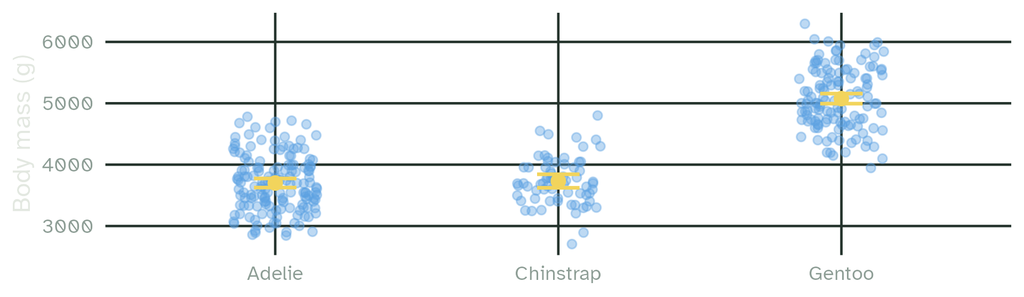

```r
ggplot(preds, aes(species, fit)) +
  geom_jitter(data = pengs, aes(y = body_mass_g), width = 0.15,
              colour = kingfisher, alpha = 0.4) +
  geom_errorbar(aes(ymin = lwr, ymax = upr), width = 0.15,
                colour = hornbill, linewidth = 1.2) +
  geom_point(colour = hornbill, size = 4) +
  labs(x = NULL, y = "Body mass (g)")
```

## Showing uncertainty: continuous

Predict over a grid of flipper lengths, within the range of the data:

```r
grid <- tibble(flipper_length_mm = seq(172, 231, by = 1))
grid <- bind_cols(grid, predict(m, newdata = grid, interval = "confidence"))
grid
```

```
# A tibble: 60 × 4
  flipper_length_mm   fit   lwr   upr
              <dbl> <dbl> <dbl> <dbl>
1               172 2765. 2669. 2861.
2               173 2815. 2721. 2908.
3               174 2864. 2774. 2955.
4               175 2914. 2826. 3002.
5               176 2964. 2878. 3049.
# ℹ 55 more rows
```

## Showing uncertainty: continuous

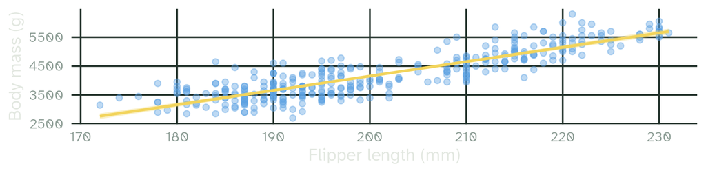

```r
ggplot(grid, aes(flipper_length_mm, fit)) +
  geom_point(data = pengs, aes(y = body_mass_g), colour = kingfisher, alpha = 0.4) +
  geom_ribbon(aes(ymin = lwr, ymax = upr), fill = hornbill, alpha = 0.35) +
  geom_line(colour = hornbill, linewidth = 1.3) +
  labs(x = "Flipper length (mm)", y = "Body mass (g)")
```

The band shows the uncertainty in the line, which is wider at the edges. `geom_smooth(method = "lm")` draws the same.

# Building models

`Did you know:` the illegal pet trade is one of the worst threats to slow lorises. Traffickers pull out their teeth so that they cannot bite.

*Sources: San Diego Zoo Wildlife Alliance; Mongabay*

## What you have learned

| Outcome | Repeated measures? | Model |
| --- | --- | --- |
| continuous | no | lm() |
| continuous | yes | lmer() |
| binary (0/1) | no | glm(family = binomial) |
| binary (0/1) | yes | glmer(family = binomial) |

We fitted `glmer()` in lecture 12; `glm()` is the same model without random effects. One framework: an outcome, a linear predictor (continuous and categorical predictors, interactions), a distribution, and random effects where the data are grouped. Counts would use Poisson regression (Winter, Ch 13).

## The cookbook approach

Many textbooks teach a cookbook: two groups → t-test; three groups → ANOVA; two numbers → correlation.

Each of these tests is a special case of the linear model; lecture 9 showed this for the t-test. The cookbook hides the assumptions behind each recipe, and it has no recipe once the data have repeated measures or several predictors. Winter recommends thinking in terms of models instead.

## Stepwise regression

Put in every predictor, and let the computer drop the useless ones:

```r
one_step <- function() {
  noise <- as_tibble(matrix(rnorm(50 * 21), ncol = 21,
                            dimnames = list(NULL, c("y", paste0("x", 1:20)))))
  best <- step(lm(y ~ ., data = noise), trace = 0)
  p <- summary(best)$coefficients[-1, 4]
  sum(p < .05)
}
```

The data have 50 rows: an outcome `y` and 20 predictors, all random noise. `y ~ .` uses every other column as a predictor, and `step()` drops predictors one at a time, as long as that improves the AIC.

## Stepwise regression finds noise

```r
set.seed(11)
n_sig <- map_dbl(1:300, \(i) one_step())
mean(n_sig >= 1)
```

```
[1] 0.8466667
```

In 85% of the data sets, the final model keeps at least one “significant” predictor, though nothing is real. Its p-values ignore all the tests that went into choosing it, a hidden case of multiple testing. Choose predictors from your research question and theory instead.

## Theory-driven modelling

Winter (Ch 16): modelling is subjective, and that is fine, as long as it is principled and transparent.

- Decide the model before seeing the data: outcome, predictors, interactions, random effects
- Keep confirmatory (planned) and exploratory (after the fact) analyses apart, and label them
- Consider preregistering the analysis
- Report the choices you made, and why

## Reproducible research

Someone else, or you in a year, should get the same results from your data.

| Practice | Instead of |
| --- | --- |
| the whole analysis as code, e.g. in R Markdown | clicking and copying results by hand |
| `set.seed()` before simulations or `sample()` | different random numbers on every run |
| R projects and relative paths | `C:/Users/me/Desktop/...` |
| `sessionInfo()` to record package versions | guessing which version gave the result |
| data and code shared with the paper, e.g. on the OSF | “available on request” |

# Your turn

## Exercises

1. Use `sim_study()` to estimate the power to detect a 20 ms difference (SD = 40) with 20 and with 50 speakers per group. Check your answers with `power.t.test()`
2. A study reports these p-values for 6 tests: 0.001, 0.008, 0.02, 0.04, 0.045, 0.3. Which remain below .05 after a Holm correction?
3. Fit `flipper_length_mm ~ species` on `pengs`. Test `species` with a model comparison, and plot the predicted means with their 95% CIs

## Solutions

```r
set.seed(1)
mean(map_dbl(1:1000, \(i) sim_study(n = 20, diff = 20)$p) < .05)
```

```
[1] 0.331
```

```r
mean(map_dbl(1:1000, \(i) sim_study(n = 50, diff = 20)$p) < .05)
```

```
[1] 0.717
```

```r
power.t.test(n = c(20, 50), delta = 20, sd = 40)$power
```

```
[1] 0.3377084 0.6968888
```

Doubling the effect makes a huge difference: with 50 speakers per group, power is about 70%.

## Solutions

```r
p_ex <- c(0.001, 0.008, 0.02, 0.04, 0.045, 0.3)
p.adjust(p_ex, method = "holm")
```

```
[1] 0.006 0.040 0.080 0.120 0.120 0.300
```

Only the first two (0.006 and 0.04) stay below .05.

## Solutions

```r
pengs_f <- penguins |> drop_na(flipper_length_mm, species)
m_fl <- lm(flipper_length_mm ~ species, data = pengs_f)
anova(lm(flipper_length_mm ~ 1, data = pengs_f), m_fl)$`Pr(>F)`[2]
```

```
[1] 1.35171e-111
```

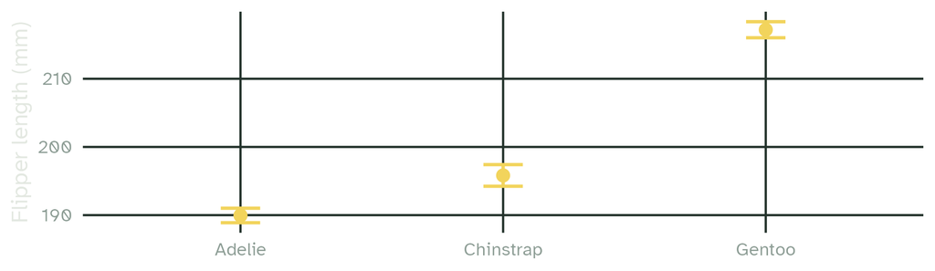

```r
preds_fl <- bind_cols(new_sp, predict(m_fl, newdata = new_sp, interval = "confidence"))
ggplot(preds_fl, aes(species, fit)) +
  geom_errorbar(aes(ymin = lwr, ymax = upr), width = 0.15, colour = hornbill, linewidth = 1.2) +
  geom_point(colour = hornbill, size = 4) + labs(x = NULL, y = "Flipper length (mm)")
```

## Summary

- A p-value is not the probability that the null is true; p > .05 is not “no effect”; compare effects directly
- Low power misses real effects, and exaggerates the ones it finds (Type M and S errors)
- Simulate to find out the power of a design, including mixed models
- Many tests and peeking at the data inflate false alarms: plan in advance
- Report confidence intervals, and plot uncertainty
- Build models from theory instead of stepwise selection; keep your analysis reproducible

## References

- Gelman, A., & Carlin, J. (2014). Beyond power calculations: Assessing Type S (sign) and Type M (magnitude) errors. *Perspectives on Psychological Science*, 9(6), 641–651. https://doi.org/10.1177/1745691614551642
- Gelman, A., & Stern, H. (2006). The difference between “significant” and “not significant” is not itself statistically significant. *The American Statistician*, 60, 328–331. https://doi.org/10.1198/000313006X152649
- Green, P., & MacLeod, C. J. (2016). SIMR: An R package for power analysis of generalized linear mixed models by simulation. *Methods in Ecology and Evolution*. https://doi.org/10.1111/2041-210X.12504
- Winter, B. (2019). *Statistics for linguists: An introduction using R*. Routledge.

## Slides and code

[figure not shown]

These slides

mcanzi.de/ws26_statistics/13_power_and_models.html

Code, data and all lectures

github.com/mcanzi/ws26_statistics